# Exam 2

This exam uses graduation.csv data for examining differences in time to graduation among undergraduate students. Because of the way this data was created, the time outcome is somewhat strange, just interpret estimates as increase/decrease and multiplicatively as appropriate for the model (don’t attempt to state units).

| name | variable |
| --- | --- |
| id | row number |
| time | time to undergraduate graduation |
| event | a binary indicator of graduation (1 yes 0 no) |
| prttime | a binary indicator of if the student is parttime or not (1 yes 0 no) |
| age | age at college enrollment |
| gpa | student’s GPA at the start of their 2nd year |
| dblmaj | a binary indicator of if the student is a double major or not |

```r
library(tidyverse)
link="https://raw.githubusercontent.com/rixj/Biostatistical-Analysis/master/graduation.csv"
dat = read_csv(file = url(link))
attach(dat)
library(survival)
```

# Problem 1

In survival analysis, the summary table 1 typically examines how the covariates (parttime, age, gpa, dblmaj) differ by event status. Be sure to include counts/measures of center and measure of significance. Create a single summary table 1, include appropriate figures, and write an interpretive paragraph.

```r
sfit1 = survfit(Surv(time, event)~prttime)
chisq.test(table(prttime,event))
```

```
    Pearson's Chi-squared test with Yates' continuity correction

data:  table(prttime, event)
X-squared = 203.54, df = 1, p-value < 2.2e-16
```

[figure not shown]

```r
plot(sfit1,ylab=expression(hat(S)*"(t)"),xlab="t",col=1:2)
legend("bottomright",c("Part-time","Full-time"),col=1:2,lty=1,bty="n")
```

```r
sfit2 = survfit(Surv(time, event)~age)
t.test(age[event==1],age[event==0])
```

```
    Welch Two Sample t-test

data:  age[event == 1] and age[event == 0]
t = 4.0075, df = 218.98, p-value = 8.413e-05
alternative hypothesis: true difference in means is not equal to 0
95 percent confidence interval:
 0.2068605 0.6072212
sample estimates:
mean of x mean of y
 18.61134  18.20430
```

[figure not shown]

```r
age2=ifelse(age>25,2,age)
age1=ifelse(age2>20,1,age2)
ageA=ifelse(age1>2,0,age1)
sfit2a = survfit(Surv(time, event)~ageA)
plot(sfit2a,ylab=expression(hat(S)*"(t)"),xlab="t",col=1:3)
legend("bottomright",c("Age=26+","Age=21-25","Age=17-20"),col=1:3,lty=1,bty="n")
```

```r
sfit3 = survfit(Surv(time, event)~gpa)
t.test(gpa[event==1],gpa[event==0])
```

```
    Welch Two Sample t-test

data:  gpa[event == 1] and gpa[event == 0]
t = 1.1947, df = 200.48, p-value = 0.2336
alternative hypothesis: true difference in means is not equal to 0
95 percent confidence interval:
 -0.02530607  0.10311720
sample estimates:
mean of x mean of y
 3.115787  3.076882
```

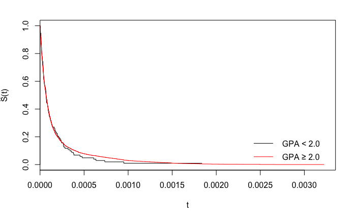

```r
sfit3a = survfit(Surv(time, event)~ifelse(gpa<2,0,1))
plot(sfit3a,ylab=expression(hat(S)*"(t)"),xlab="t",col=1:2)
legend("bottomright",c("GPA < 2.0","GPA ≥ 2.0"),col=1:2,lty=1,bty="n")
```

```r
sfit4 = survfit(Surv(time, event)~dblmaj)
chisq.test(table(dblmaj,event))
```

```
    Pearson's Chi-squared test with Yates' continuity correction

data:  table(dblmaj, event)
X-squared = 0.0079701, df = 1, p-value = 0.9289
```

[figure not shown]

```r
plot(sfit4,ylab=expression(hat(S)*"(t)"),xlab="t",col=1:2)
legend("bottomright",c("Double-major","Single-major"),col=1:2,lty=1,bty="n")
```

# Summary Table 1

|  | Mean ± SD | Min, Max | Critical Value | df | P-Value |
| --- | --- | --- | --- | --- | --- |
| prttime | - | - | χ² = 203.54 | 1 | < 2.2e-16 |
| age | 18.60 ± 1.99 | 17, 41 | t = 4.0075 | 218.98 | 8.41E-05 |
| gpa | 3.11 ± 0.45 | 0.5, 4 | t = 1.1947 | 200.48 | 0.2336 |
| dblmaj | - | - | χ² = 0.0079701 | 1 | 0.9289 |

Our p-values in Summary Table 1 show that prttime and age are the only significant factors in relation to event. Looking at the output of the table() functions, I have created the table below to describe general trends in the data. Looking at the table, part-time students are less likely to graduate. Every student who was older than 25 graduated. Older students were more likely to graduate. Surprisingly, students with a GPA < 2.0 were more likely to graduate than higher-GPA students. Double-major students were at the same graduation rate as peers who did not.

**Overview of Data from table() functions**

|  | Value | n | Dropped | Graduated | Survival rate |
| --- | --- | --- | --- | --- | --- |
| event | - | 5000 | 186 | 4814 | 0.9628 |
| prttime | 0 | 3955 | 69 | 3886 | 0.982553729 |
|  | 1 | 1045 | 117 | 928 | 0.888038278 |
| gpa | GPA = 0-1.9 | 110 | 3 | 107 | 0.972727273 |
|  | GPA = 2.0-4.0 | 4890 | 183 | 4707 | 0.962576687 |
| age | 26 years + | 75 | 0 | 75 | 1 |
|  | 21-25 years | 442 | 8 | 434 | 0.981900452 |
|  | 17-20 years | 4483 | 178 | 4305 | 0.960294446 |
| dblmaj | 0 | 4006 | 150 | 3856 | 0.962556166 |
|  | 1 | 994 | 36 | 958 | 0.963782696 |

```r
library(oddsratio)
fitglm = glm(event~prttime+age+gpa+dblmaj, family="binomial")
logit = fitglm$coefficients
exp(logit)                # odds ratio
exp(logit)/(1+exp(logit)) # probability
```

**Odds-ratio Table**

|  | odds ratio | probability |
| --- | --- | --- |
| prttime | 0.1392271 | 0.1222119 |
| age | 1.1809622 | 0.5414868 |
| gpa | 1.2274882 | 0.5510638 |
| dblmaj | 1.0118082 | 0.5029347 |

I calculated odds-ratio to show a more direct correlation between the covariates and the response variable.

# Problem 2

Fit a survival model for the data of interest. Present your best model. Explain why you fit the model you do, what covariates you use and why, examine model diagnostics, and write an interpretive paragraph.

We will use Regression for a Parametric Survival Model survreg()

```r
coxfit1 <- coxph(Surv(time, event)~prttime)
summary(coxfit1)
```

```
Call:
coxph(formula = Surv(time, event) ~ prttime)

  n= 5000, number of events= 4814

            coef exp(coef) se(coef)      z Pr(>|z|)
prttime -1.92532   0.14583  0.04844 -39.75   <2e-16 ***
---
Signif. codes:  0 ‘***’ 0.001 ‘**’ 0.01 ‘*’ 0.05 ‘.’ 0.1 ‘ ’ 1

        exp(coef) exp(-coef) lower .95 upper .95
prttime    0.1458      6.857    0.1326    0.1604

Concordance= 0.625  (se = 0.004 )
Rsquare= 0.352   (max possible= 1 )
Likelihood ratio test= 2170  on 1 df,   p=<2e-16
Wald test            = 1580  on 1 df,   p=<2e-16
Score (logrank) test = 1836  on 1 df,   p=<2e-16
```

```r
survreg(Surv(time, event)~prttime ,dist='weibull')
```

```
Call:
survreg(formula = Surv(time, event) ~ prttime, dist = "weibull")

Coefficients:
(Intercept)     prttime
  -9.517448    1.942830

Scale= 1.007451

Loglik(model)= 39186.3   Loglik(intercept only)= 37857.9
    Chisq= 2656.77 on 1 degrees of freedom, p= <2e-16
n= 5000
```

```r
coxfit2 <- coxph(Surv(time, event)~age)
summary(coxfit2)
```

```
Call:
coxph(formula = Surv(time, event) ~ age)

  n= 5000, number of events= 4814

        coef exp(coef) se(coef)     z Pr(>|z|)
age 0.060870  1.062761 0.007173 8.486   <2e-16 ***
---
Signif. codes:  0 ‘***’ 0.001 ‘**’ 0.01 ‘*’ 0.05 ‘.’ 0.1 ‘ ’ 1

    exp(coef) exp(-coef) lower .95 upper .95
age     1.063     0.9409     1.048     1.078

Concordance= 0.534  (se = 0.005 )
Rsquare= 0.013   (max possible= 1 )
Likelihood ratio test= 63.05  on 1 df,   p=2e-15
Wald test            = 72.01  on 1 df,   p=<2e-16
Score (logrank) test = 71.66  on 1 df,   p=<2e-16
```

```r
survreg(Surv(time, event)~age ,dist='weibull')
```

```
Call:
survreg(formula = Surv(time, event) ~ age, dist = "weibull")

Coefficients:
(Intercept)         age
 -7.4571943  -0.0814839

Scale= 1.372987

Loglik(model)= 37887.8   Loglik(intercept only)= 37857.9
    Chisq= 59.78 on 1 degrees of freedom, p= 1.06e-14
n= 5000
```

```r
coxfit3 <- coxph(Surv(time, event)~gpa)
summary(coxfit3)
```

```
Call:
coxph(formula = Surv(time, event) ~ gpa)

  n= 5000, number of events= 4814

        coef exp(coef) se(coef)     z Pr(>|z|)
gpa 0.007329  1.007356 0.032004 0.229    0.819

    exp(coef) exp(-coef) lower .95 upper .95
gpa     1.007     0.9927    0.9461     1.073

Concordance= 0.497  (se = 0.005 )
Rsquare= 0   (max possible= 1 )
Likelihood ratio test= 0.05  on 1 df,   p=0.8
Wald test            = 0.05  on 1 df,   p=0.8
Score (logrank) test = 0.05  on 1 df,   p=0.8
```

```r
survreg(Surv(time, event)~gpa ,dist='weibull')
```

```
Call:
survreg(formula = Surv(time, event) ~ gpa, dist = "weibull")

Coefficients:
 (Intercept)          gpa
-8.943962982 -0.007640826

Scale= 1.379062

Loglik(model)= 37857.9   Loglik(intercept only)= 37857.9
    Chisq= 0.03 on 1 degrees of freedom, p= 0.863
n= 5000
```

```r
coxfit4 <- coxph(Surv(time, event)~dblmaj)
summary(coxfit4)
```

```
Call:
coxph(formula = Surv(time, event) ~ dblmaj)

  n= 5000, number of events= 4814

           coef exp(coef) se(coef)      z Pr(>|z|)
dblmaj -0.08151   0.92173  0.03612 -2.257    0.024 *
---
Signif. codes:  0 ‘***’ 0.001 ‘**’ 0.01 ‘*’ 0.05 ‘.’ 0.1 ‘ ’ 1

       exp(coef) exp(-coef) lower .95 upper .95
dblmaj    0.9217      1.085    0.8587    0.9893

Concordance= 0.512  (se = 0.003 )
Rsquare= 0.001   (max possible= 1 )
Likelihood ratio test= 5.18  on 1 df,   p=0.02
Wald test            = 5.09  on 1 df,   p=0.02
Score (logrank) test = 5.09  on 1 df,   p=0.02
```

```r
survreg(Surv(time, event)~dblmaj ,dist='weibull')
```

```
Call:
survreg(formula = Surv(time, event) ~ dblmaj, dist = "weibull")

Coefficients:
(Intercept)      dblmaj
-8.98533475  0.08610199

Scale= 1.379063

Loglik(model)= 37859.4   Loglik(intercept only)= 37857.9
    Chisq= 3.03 on 1 degrees of freedom, p= 0.0818
n= 5000
```

```r
coxfitA <- coxph(Surv(time, event)~prttime+age)
summary(coxfitA)
```

```
Call:
coxph(formula = Surv(time, event) ~ prttime + age)

  n= 5000, number of events= 4814

             coef exp(coef)  se(coef)      z Pr(>|z|)
prttime -1.980324  0.138024  0.048851 -40.54   <2e-16 ***
age      0.099448  1.104561  0.007201  13.81   <2e-16 ***
---
Signif. codes:  0 ‘***’ 0.001 ‘**’ 0.01 ‘*’ 0.05 ‘.’ 0.1 ‘ ’ 1

        exp(coef) exp(-coef) lower .95 upper .95
prttime     0.138     7.2451    0.1254    0.1519
age         1.105     0.9053    1.0891    1.1203

Concordance= 0.655  (se = 0.005 )
Rsquare= 0.372   (max possible= 1 )
Likelihood ratio test= 2326  on 2 df,   p=<2e-16
Wald test            = 1733  on 2 df,   p=<2e-16
Score (logrank) test = 1978  on 2 df,   p=<2e-16
```

```r
survreg(Surv(time, event)~prttime+age ,dist='weibull')
```

```
Call:
survreg(formula = Surv(time, event) ~ prttime + age, dist = "weibull")

Coefficients:
(Intercept)     prttime         age
-7.69730343  1.95993399 -0.09848594

Scale= 0.990124

Loglik(model)= 39264.5   Loglik(intercept only)= 37857.9
    Chisq= 2813.12 on 2 degrees of freedom, p= <2e-16
n= 5000
```

```r
coxfitB <- coxph(Surv(time, event)~prttime+age+dblmaj)
summary(coxfitB)
```

```
Call:
coxph(formula = Surv(time, event) ~ prttime + age + dblmaj)

  n= 5000, number of events= 4814

             coef exp(coef)  se(coef)       z Pr(>|z|)
prttime -1.998842  0.135492  0.049110 -40.701  < 2e-16 ***
age      0.100201  1.105394  0.007175  13.966  < 2e-16 ***
dblmaj  -0.196915  0.821261  0.036252  -5.432 5.58e-08 ***
---
Signif. codes:  0 ‘***’ 0.001 ‘**’ 0.01 ‘*’ 0.05 ‘.’ 0.1 ‘ ’ 1

        exp(coef) exp(-coef) lower .95 upper .95
prttime    0.1355     7.3805    0.1231    0.1492
age        1.1054     0.9047    1.0900    1.1210
dblmaj     0.8213     1.2176    0.7649    0.8817

Concordance= 0.66  (se = 0.005 )
Rsquare= 0.376   (max possible= 1 )
Likelihood ratio test= 2357  on 3 df,   p=<2e-16
Wald test            = 1755  on 3 df,   p=<2e-16
Score (logrank) test = 2002  on 3 df,   p=<2e-16
```

```r
survreg(Surv(time, event)~prttime+age+dblmaj ,dist='weibull')
```

```
Call:
survreg(formula = Surv(time, event) ~ prttime + age + dblmaj,
    dist = "weibull")

Coefficients:
(Intercept)     prttime         age      dblmaj
-7.73359836  1.96825770 -0.09877631  0.19381565

Scale= 0.9859311

Loglik(model)= 39279.8   Loglik(intercept only)= 37857.9
    Chisq= 2843.74 on 3 degrees of freedom, p= <2e-16
n= 5000
```

```r
summary(coxph(Surv(time, event)~prttime+age+dblmaj+gpa))
```

```
Call:
coxph(formula = Surv(time, event) ~ prttime + age + dblmaj +
    gpa)

  n= 5000, number of events= 4814

            coef exp(coef) se(coef)       z Pr(>|z|)
prttime -2.00086   0.13522  0.04921 -40.659  < 2e-16 ***
age      0.10013   1.10532  0.00717  13.965  < 2e-16 ***
dblmaj  -0.19645   0.82164  0.03626  -5.419 6.01e-08 ***
gpa      0.03059   1.03106  0.03094   0.989    0.323
---
Signif. codes:  0 ‘***’ 0.001 ‘**’ 0.01 ‘*’ 0.05 ‘.’ 0.1 ‘ ’ 1

        exp(coef) exp(-coef) lower .95 upper .95
prttime    0.1352     7.3954    0.1228    0.1489
age        1.1053     0.9047    1.0899    1.1210
dblmaj     0.8216     1.2171    0.7653    0.8822
gpa        1.0311     0.9699    0.9704    1.0955

Concordance= 0.659  (se = 0.005 )
Rsquare= 0.376   (max possible= 1 )
Likelihood ratio test= 2358  on 4 df,   p=<2e-16
Wald test            = 1752  on 4 df,   p=<2e-16
Score (logrank) test = 2002  on 4 df,   p=<2e-16
```

```r
survreg(Surv(time, event)~prttime+age+dblmaj+gpa,dist='weibull')
```

```
Call:
survreg(formula = Surv(time, event) ~ prttime + age + dblmaj +
    gpa, dist = "weibull")

Coefficients:
(Intercept)     prttime         age      dblmaj         gpa
-7.64316279  1.96859200 -0.09866727  0.19325681 -0.02965125

Scale= 0.9855962

Loglik(model)= 39280.2   Loglik(intercept only)= 37857.9
    Chisq= 2844.69 on 4 degrees of freedom, p= <2e-16
n= 5000
```

| Model variables | Rsquare | Likelihood ratio test | survreg |
| --- | --- | --- | --- |
| prttime | 0.352 | 2170 on 1 df p=<2e-16 | χ² = 2656.77 on 1 df p=<2e-16 |
| age | 0.013 | 63.05 on 1 df p=2e-15 | χ² = 59.78 on 1 df p=1.06e-14 |
| gpa | 0 | 0.05 on 1 df p=0.8 | χ² = 0.03 on 1 df p=0.863 |
| dlbmaj | 0.001 | 5.18 on 1 df p=0.02 | χ² = 3.03 on 1 df p=0.0818 |
| prttime+age | 0.372 | 2326 on 2 df p=<2e-16 | χ² = 2813.12 on 2 df p=<2e-16 |
| prttime+age+dlbmaj | 0.376 | 2357 on 3 df p=<2e-16 | χ² = 2843.74 on 3 df p=<2e-16 |
| prttime+age+dblmaj+gpa | 0.376 | 2358 on 4 df p=<2e-16 | χ² = 2844.69 on 4 df p=<2e-16 |

# Problem 3

Consider the GPA variable. It may be more informative to examine a binary version of this variable, e.g. if the student had a failing GPA at the start of their 2nd year. Examine model diagnostics and write an interpretive paragraph. Also, examine and explain how this consideration alters your model from your best model. Is there any concern with altering the GPA variable in this way?

Do D’s get degrees? Some colleges accept D’s as a passing grade as long as your overall GPA is higher than a C. So in this regard we will say that failing students are sophomores with below a C average GPA.

## gpa as a continuous variable

```r
t.test(gpa[event==1],gpa[event==0])
```

```
    Welch Two Sample t-test

data:  gpa[event == 1] and gpa[event == 0]
t = 1.1947, df = 200.48, p-value = 0.2336
alternative hypothesis: true difference in means is not equal to 0
95 percent confidence interval:
 -0.02530607  0.10311720
sample estimates:
mean of x mean of y
 3.115787  3.076882
```

```r
# survdiff(Surv(time, event)~gpa)
# I ran the code, but the results are too long. Check the table for the result, or uncomment this.
summary(coxph(Surv(time, event)~gpa))
```

```
Call:
coxph(formula = Surv(time, event) ~ gpa)

  n= 5000, number of events= 4814

        coef exp(coef) se(coef)     z Pr(>|z|)
gpa 0.007329  1.007356 0.032004 0.229    0.819

    exp(coef) exp(-coef) lower .95 upper .95
gpa     1.007     0.9927    0.9461     1.073

Concordance= 0.497  (se = 0.005 )
Rsquare= 0   (max possible= 1 )
Likelihood ratio test= 0.05  on 1 df,   p=0.8
Wald test            = 0.05  on 1 df,   p=0.8
Score (logrank) test = 0.05  on 1 df,   p=0.8
```

```r
survreg(Surv(time, event)~gpa ,dist='weibull')
```

```
Call:
survreg(formula = Surv(time, event) ~ gpa, dist = "weibull")

Coefficients:
 (Intercept)          gpa
-8.943962982 -0.007640826

Scale= 1.379062

Loglik(model)= 37857.9   Loglik(intercept only)= 37857.9
    Chisq= 0.03 on 1 degrees of freedom, p= 0.863
n= 5000
```

```r
# survdiff(Surv(time, event)~prttime+age+dblmaj+gpa)
# I ran the code, but the results are too long. Check the table for the result, or uncomment this.
summary(coxph(Surv(time, event)~prttime+age+dblmaj+gpa))
```

```
Call:
coxph(formula = Surv(time, event) ~ prttime + age + dblmaj +
    gpa)

  n= 5000, number of events= 4814

            coef exp(coef) se(coef)       z Pr(>|z|)
prttime -2.00086   0.13522  0.04921 -40.659  < 2e-16 ***
age      0.10013   1.10532  0.00717  13.965  < 2e-16 ***
dblmaj  -0.19645   0.82164  0.03626  -5.419 6.01e-08 ***
gpa      0.03059   1.03106  0.03094   0.989    0.323
---
Signif. codes:
0 ‘***’ 0.001 ‘**’ 0.01 ‘*’ 0.05 ‘.’ 0.1 ‘ ’ 1

        exp(coef) exp(-coef) lower .95 upper .95
prttime    0.1352     7.3954    0.1228    0.1489
age        1.1053     0.9047    1.0899    1.1210
dblmaj     0.8216     1.2171    0.7653    0.8822
gpa        1.0311     0.9699    0.9704    1.0955

Concordance= 0.659  (se = 0.005 )
Rsquare= 0.376   (max possible= 1 )
Likelihood ratio test= 2358  on 4 df,   p=<2e-16
Wald test            = 1752  on 4 df,   p=<2e-16
Score (logrank) test = 2002  on 4 df,   p=<2e-16
```

```r
survreg(Surv(time, event)~prttime+age+dblmaj+gpa,dist='weibull')
```

```
Call:
survreg(formula = Surv(time, event) ~ prttime + age + dblmaj +
    gpa, dist = "weibull")

Coefficients:
(Intercept)     prttime         age      dblmaj
-7.64316279  1.96859200 -0.09866727  0.19325681
        gpa
-0.02965125

Scale= 0.9855962

Loglik(model)= 39280.2   Loglik(intercept only)= 37857.9
    Chisq= 2844.69 on 4 degrees of freedom, p= <2e-16
n= 5000
```

## gpa as a categorical variable

```r
t.test(table(ifelse(gpa<2,0,1),event))
```

```
    One Sample t-test

data:  table(ifelse(gpa < 2, 0, 1), event)
t = 1.0842, df = 3, p-value = 0.3576
alternative hypothesis: true mean is not equal to 0
95 percent confidence interval:
 -2419.118  4919.118
sample estimates:
mean of x
     1250
```

```r
# survdiff(Surv(time, event)~ifelse(gpa<2,0,1))
# I ran the code, but the results are too long. Check the table for the result, or uncomment this.
summary(coxph(Surv(time, event)~ifelse(gpa<2,0,1)))
```

```
Call:
coxph(formula = Surv(time, event) ~ ifelse(gpa < 2, 0, 1))

  n= 5000, number of events= 4814

                          coef exp(coef) se(coef)      z Pr(>|z|)
ifelse(gpa < 2, 0, 1) -0.02614   0.97420  0.09779 -0.267    0.789

                      exp(coef) exp(-coef) lower .95 upper .95
ifelse(gpa < 2, 0, 1)    0.9742      1.026    0.8043      1.18

Concordance= 0.5  (se = 0.001 )
Rsquare= 0   (max possible= 1 )
Likelihood ratio test= 0.07  on 1 df,   p=0.8
Wald test            = 0.07  on 1 df,   p=0.8
Score (logrank) test = 0.07  on 1 df,   p=0.8
```

```r
survreg(Surv(time, event)~ifelse(gpa<2,0,1) ,dist='weibull')
```

```
Call:
survreg(formula = Surv(time, event) ~ ifelse(gpa < 2, 0, 1),
    dist = "weibull")

Coefficients:
          (Intercept) ifelse(gpa < 2, 0, 1)
          -9.03907923            0.07293427

Scale= 1.378966

Loglik(model)= 37858   Loglik(intercept only)= 37857.9
    Chisq= 0.29 on 1 degrees of freedom, p= 0.592
n= 5000
```

```r
# survdiff(Surv(time, event)~prttime+age+dblmaj+ifelse(gpa<2,0,1))
# I ran the code, but the results are too long. Check the table for the result, or uncomment this.
summary(coxph(Surv(time, event)~prttime+age+dblmaj+ifelse(gpa<2,0,1)))
```

```
Call:
coxph(formula = Surv(time, event) ~ prttime + age + dblmaj +
    ifelse(gpa < 2, 0, 1))

  n= 5000, number of events= 4814

                           coef exp(coef)  se(coef)       z Pr(>|z|)
prttime               -2.002765  0.134962  0.049250 -40.665   <2e-16 ***
age                    0.100481  1.105703  0.007178  13.998   <2e-16 ***
dblmaj                -0.196455  0.821638  0.036255  -5.419    6e-08 ***
ifelse(gpa < 2, 0, 1)  0.150399  1.162298  0.097947   1.536    0.125
---
Signif. codes:  0 ‘***’ 0.001 ‘**’ 0.01 ‘*’ 0.05 ‘.’ 0.1 ‘ ’ 1

                      exp(coef) exp(-coef) lower .95 upper .95
prttime                  0.1350     7.4095    0.1225    0.1486
age                      1.1057     0.9044    1.0903    1.1214
dblmaj                   0.8216     1.2171    0.7653    0.8821
ifelse(gpa < 2, 0, 1)    1.1623     0.8604    0.9593    1.4083

Concordance= 0.66  (se = 0.005 )
Rsquare= 0.376   (max possible= 1 )
Likelihood ratio test= 2359  on 4 df,   p=<2e-16
Wald test            = 1752  on 4 df,   p=<2e-16
Score (logrank) test = 2003  on 4 df,   p=<2e-16
```

```r
survreg(Surv(time, event)~prttime+age+dblmaj+ifelse(gpa<2,0,1),dist='weibull')
```

```
Call:
survreg(formula = Surv(time, event) ~ prttime + age + dblmaj +
    ifelse(gpa < 2, 0, 1), dist = "weibull")

Coefficients:
          (Intercept)               prttime                   age
           -7.5844561             1.9699635            -0.0989897
               dblmaj ifelse(gpa < 2, 0, 1)
            0.1932244            -0.1487368

Scale= 0.9853949

Loglik(model)= 39281   Loglik(intercept only)= 37857.9
    Chisq= 2846.24 on 4 degrees of freedom, p= <2e-16
n= 5000
```

## Results

|  | T-test | survdiff | Rsquared | coxph_LikelihoodRT | survreg |
| --- | --- | --- | --- | --- | --- |
| gpa | t = 1.1947, df=200.48, p=0.2336 | χ² = 37.9, 34 df, p=0.3 | 0 | 0.05, 1 df, p=0.8 | χ² = 0, 1 df, p=0.863 |
| gpaCategorical | t = 1.0842, df=3, p=0.3576 | χ² = 0.1, 1 df, p=0.8 | 0 | 0.07, 1 df, p=0.8 | χ² = 0, 1 df, p=0.592 |
| prttime+age+dblmaj+gpa | - | χ² = 4855, 568 df, p=<2e-16 | 0.376 | 2358 on 4 df, p=<2e-16 | χ² = 2844.69, 4 df, p=<2e-16 |
| prttime+age+dblmaj+gpaC | - | χ² = 2371, 85 df, p=<2e-16 | 0.376 | 2359 on 4 df, p=<2e-16 | χ² = 2846.24, 4 df, p=<2e-16 |

When gpa is a binary value and determined by sophomores who have a GPA < 2, the p-value decreases from 0.86 to 0.59 but it is still not a significant value to be incorporated into our model. But when we look at the model with all 4 factors it is more significant than the model holding only the significantly associated variables (prttime & age). When we compare our chosen model (model with all 4 covariates) with our categorized gpa model (which also has all 4 covariates), we see that the χ²-test-statistic is slightly higher, 2846.24 vs. 2844.69 but nothing significantly different. Thus, gpa should not be categorized and we shall keep our previous model.

# Problem 4

Fit a logistic model for the event indicator rather than a survival model (pick your covariate set from either 2 or 3). Make interpretations and comparisons. Is this a better way to examine this data? Why or why not?

```r
glmfit = glm(event~prttime+age+gpa+dblmaj,family=binomial(link=logit))
summary(glmfit)
```

```
Call:
glm(formula = event ~ prttime + age + gpa + dblmaj, family = binomial(link = logit))

Deviance Residuals:
    Min       1Q   Median       3Q      Max
-3.2509   0.1779   0.1932   0.2129   0.6273

Coefficients:
            Estimate Std. Error z value Pr(>|z|)
(Intercept)  0.34209    1.16640   0.293  0.76930
prttime     -1.97165    0.15648 -12.600  < 2e-16 ***
age          0.16633    0.05697   2.920  0.00351 **
gpa          0.20497    0.16601   1.235  0.21694
dblmaj       0.01174    0.19338   0.061  0.95160
---
Signif. codes:  0 ‘***’ 0.001 ‘**’ 0.01 ‘*’ 0.05 ‘.’ 0.1 ‘ ’ 1

(Dispersion parameter for binomial family taken to be 1)

    Null deviance: 1589.4  on 4999  degrees of freedom
Residual deviance: 1416.0  on 4995  degrees of freedom
AIC: 1426

Number of Fisher Scoring iterations: 7
```

Using the logistic model we get the null deviance and residual deviance so we can compare the null model to our model and we calculate the p-value which is 0, asserting that this is a significant model. When testing the association between the factors and graduating we reject the null hypothesis at the 0.05 alpha level. We can also check the log odds ratio.

```r
fitglm = glm(event~prttime+age+gpa+dblmaj, family="binomial")
logit = fitglm$coefficients
exp(logit)                # odds ratio
```

```
(Intercept)     prttime         age         gpa      dblmaj
  1.4078846   0.1392271   1.1809622   1.2274882   1.0118082
```

```r
exp(logit)/(1+exp(logit)) # probability
```

```
(Intercept)     prttime         age         gpa      dblmaj
  0.5846977   0.1222119   0.5414868   0.5510638   0.5029347
```

```r
preds = predict(glmfit, dat[,4:5])
nroc = roc(event, preds)
auc(nroc)
```

```
Area under the curve: 0.7506
```

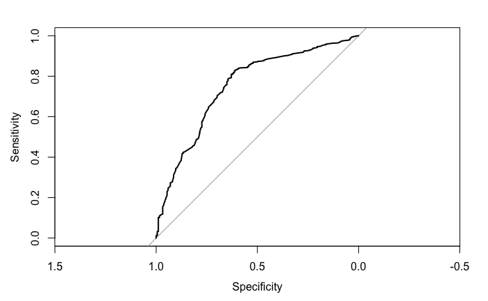

```r
plot(nroc)
```

# Tricks

```r
getS3method("summary","coxph")     # Look how a formula is calculated
# run = *Cmd+Shift+Enter*
# insert = *Cmd+Option+I*
# preview the HTML = *Cmd+Shift+K*
```